# INSY 5378 Data Science Final Project

Fake News Detection (Dataset source: Kaggle https://www.kaggle.com/competitions/fake-news)

Team members : Anmol Chadha, Ruchi Shukla, Shreya Agrawal Submitted on : 07/25/2022

The deliberate broadcasting of false or deceptive assertions as news, where the remarks are made with the intent to mislead, is known as fake news.

Problem : Due to the widespread use of the Internet, social media, and digital platforms, anyone can disseminate false information. It is nearly impossible to stop the spread of false information. False news is being spread at an alarmingly high rate, and it is not just in the political arena but also in the fields of sports, health, history, entertainment, science, and research.

Solution : Knowing the difference between fake and accurate news is essential. One approach is to have an expert make the decision and verify the accuracy of all the information, but this takes time and requires knowledge that cannot be shared. Second, we can automate the detection of bogus news using machine learning and artificial intelligence methods. Although there are many different unstructured formats of news content available online (including documents, videos, and audio), this article will focus on news in text format. We can now identify the deceptive and untrue nature of a statement thanks to advances in machine learning and natural language processing.

In this presentation, we'll focus on:

1.Investigate and examine the fake news dataset. 2.Create a classifier that is as accurate as possible in identifying fake news.

Let's import the essential libraries for analysis:

```python
 #pip install nltk
```

```python
import pandas as pd
import numpy as np
import re
import string
import nltk
from nltk.corpus import stopwords
from nltk.stem.porter import PorterStemmer
from sklearn.feature_extraction.text import TfidfVectorizer
from sklearn.model_selection import train_test_split
from sklearn.linear_model import LogisticRegression
from sklearn.naive_bayes import MultinomialNB
from sklearn.metrics import accuracy_score
from nltk.stem import WordNetLemmatizer
from sklearn.metrics import confusion_matrix
from sklearn.metrics import classification_report
from sklearn import metrics
import itertools
```

```python
news_dataset = pd.read_csv('TrainDataset.csv') # Traindataset
```

# Data Exploration

```python
news_dataset.head()
```

|  | id | title | author | text | label |
| --- | --- | --- | --- | --- | --- |
| 0 | 0 | House Dem Aide: We Didn’t Even See Comey’s Let... | Darrell Lucus | House Dem Aide: We Didn’t Even See Comey’s Let... | 1 |
| 1 | 1 | FLYNN: Hillary Clinton, Big Woman on Campus - ... | Daniel J. Flynn | Ever get the feeling your life circles the rou... | 0 |
| 2 | 2 | Why the Truth Might Get You Fired | Consortiumnews.com | Why the Truth Might Get You Fired October 29, ... | 1 |
| 3 | 3 | 15 Civilians Killed In Single US Airstrike Hav... | Jessica Purkiss | Videos 15 Civilians Killed In Single US Airstr... | 1 |
| 4 | 4 | Iranian woman jailed for fictional unpublished... | Howard Portnoy | Print \nAn Iranian woman has been sentenced to... | 1 |

id: unique id for a news article title: title of a news article author: author of the news article text: text of the article; could be incomplete label: a label that marks the article as potentially denoted by 1 (unreliable or fake) and 0 (reliable or real).

It is a binary classification problem in which we must predict if a particular news story is reliable or not.

Kaggle provided us with three .csv files(train.csv, test.csv and submit.csv). We'll be using train.csv for spliting into train and test dataset which we will see further in this notebook.

Reading the news dataset : The dataset contains 20800 rows and 5 columns

```python
news_dataset.shape
```

```
(20800, 5)
```

```python
news_dataset.isnull().sum() # checking missing values
```

```
id           0
title      558
author    1957
text        39
label        0
dtype: int64
```

```python
#drop row with none value
# news_dataset.dropna(thresh = train.shape[1] , inplace = True)
news_dataset = news_dataset.fillna('')
news_dataset.isnull().sum()
```

```
id        0
title     0
author    0
text      0
label     0
dtype: int64
```

```python
news_dataset.author.nunique()
```

```
4202
```

```python
news_dataset.label.value_counts()
### 0 - Real News
### 1 - Fake News
```

```
1    10413
0    10387
Name: label, dtype: int64
```

```python
nltk.download('stopwords')
```

```
True
```

```python
nltk.download('wordnet')
```

```
True
```

```python
print(stopwords.words('english'))
```

```
['i', 'me', 'my', 'myself', 'we', 'our', 'ours', 'ourselves', 'you', "you're", "you've", "you'll", "you'd", 'your', 'yours', 'yourself', 'yourselves', 'he', 'him', 'his', 'himself', 'she', "she's", 'her', 'hers', 'herself', 'it', "it's", 'its', 'itself', 'they', 'them', 'their', 'theirs', 'themselve…
```

```python
news_dataset['content'] =news_dataset['author']+'  ' +news_dataset['title']+' ' +news_dataset['text']
# concatenating text columns
```

```python
print(news_dataset['content'])
```

```
0        Darrell Lucus  House Dem Aide: We Didn’t Even ...
1        Daniel J. Flynn  FLYNN: Hillary Clinton, Big W...
2        Consortiumnews.com  Why the Truth Might Get Yo...
3        Jessica Purkiss  15 Civilians Killed In Single...
4        Howard Portnoy  Iranian woman jailed for ficti...
                               ...
20795    Jerome Hudson  Rapper T.I.: Trump a ’Poster Ch...
20796    Benjamin Hoffman  N.F.L. Playoffs: Schedule, M...
20797    Michael J. de la Merced and Rachel Abrams  Mac...
20798    Alex Ansary  NATO, Russia To Hold Parallel Exe...
20799    David Swanson  What Keeps the F-35 Alive   Dav...
Name: content, Length: 20800, dtype: object
```

```python
# # Counting most frequent words to be removed from our analysis
# from collections import Counter

# # split() returns list of all the words in the string
# split_it = text.split()

# # Pass the split_it list to instance of Counter class.
# Counters_found = Counter(split_it)
# #print(Counters)

# # most_common() produces k frequently encountered
# # input values and their respective counts.
# most_occur = Counters_found.most_common(200)
# print(most_occur)
```

```python
#separting the independent variable and dependent variable
X = news_dataset.drop(columns='label', axis=1)
Y = news_dataset['label']
```

```python
Y.value_counts()
```

```
1    10413
0    10387
Name: label, dtype: int64
```

There are 10413 unreliable articles (fake or 1), compared to 10387 reliable ones (real or 0). Notice that Nearly half of the articles are fake. In order to gauge how well our model is performing when creating a classifier, we will use the accuracy metric.

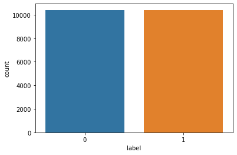

```python
# Class Distribution
# 1: Unreliable
# 2: Reliable
import seaborn as sns
sns.countplot(x='label', data= news_dataset)
```

Stemming the words: Stemming and Lemmatization are the techniques to reduce the words to their stems or roots. The main advantage of this step is to reduce the size of the vocabulary. For example, words like Play, Playing, Played will be reduced to “Play”. More Examples : Stay, Stays, Staying, Stayed — -> Stay House, Houses, Housing — -> House

```python
port_stemming = PorterStemmer()
wnl = WordNetLemmatizer()
```

```python
# ! pip install spacy
```

```python
# !python -m spacy download en_core_web_sm
```

```python
import spacy
# nlp = spacy.load('en_core_web_sm')
```

```python
def cleaning_data(content) :

    #regex to remove any numbers or special characters from the text
    review = re.sub('[^a-zA-Z]',' ',content)
    #convert text into lower case
    review = review.lower()
    #split the data and make token
    review = review.split()

#Lemmatizaton the words and remove stop words as explained above
    review = [wnl.lemmatize(word)  for word in review if not word in stopwords.words('english')]

    review = '  '.join(review)

    return review
```

```python
#Most frequent words(verbs, nouns) to be removed

most_freq_verbs = ['be','have','do','say','get',
'make',
'go',
'know',
'take',
'see',
'come',
'think',
'look',
'want',
'give',
'use',
'find',
'tell',
'ask',
'work',
'seem',
'feel',
'try',
'leave',
'call',
'time',
'person',
'year',
'way',
'day',
'thing',
'man',
'world',
'life',
'hand',
'part',
'child',
'eye',
'woman',
'place',
'work',
'week',
'case',
'point',
'government',
'company',
'number',
'group',
'problem',
'fact',
'like','many','said','u','make','us','one','would','also','time']
for i in most_freq_verbs:
    stopwords.words("english").append(i)
```

```python
stop_words = set(stopwords.words("english"))

TEXT_CLEANING_RE = "@\S+|https?:\S+|http?:\S|[^A-Za-z0-9]+" # cleaning text

def cleaning_data(text, stem=False):
    # Remove link,user and special characters
    text = re.sub(TEXT_CLEANING_RE, ' ', str(text).lower()).strip()
    tokens = []
    for token in text.split():
        if token not in stop_words:
            if stem:
                tokens.append(stemmer.stem(token))
            else:
                tokens.append(token)
    return " ".join(tokens)
```

```python
df = news_dataset.copy()
```